# Relatório Chamados LigueDja

Visão dos chamados nos anos 2021 a 2022

Fernanda Bruno

2023-11-25

[figure not shown]

Este relatório tem objetivo dar visibilidade para o corpo gerencial dos chamados abertos pelos clientes da empresa de telecomunicações **LigueDjá**.

Serão apresentados gráficos e suas respectivas análises de modo a apoiar melhora nos processos internos da empresa, focando na evolução do atendimento.

## Visão Geral

Aqui são apresentados a quantidade de chamados abertos por tipo ao longo do tempo, ou seja, chamados de **Reclamação** ou **Elogio**.

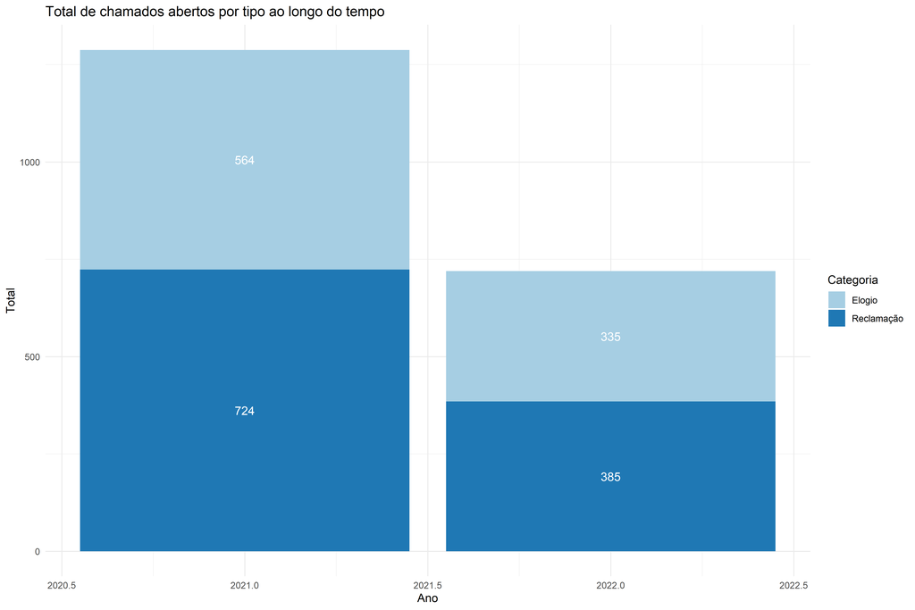

Os dados analisados compreendem o período de 2021 a 2022 e foram analisados o total de 2008 demandas.

Vamos observar os principais causas de reclamações ordenadas :

| Ano | Boleto não foi recebido | Internet intermitente | Internet lenta | Linha cruzada | Preço do plano | Queda de internet | Telefone com ruído | Telefone sem sinal |
| --- | --- | --- | --- | --- | --- | --- | --- | --- |
| 2021 | 24 | 69 | 87 | 90 | 51 | 242 | 19 | 142 |
| 2022 | 10 | 41 | 22 | 109 | 13 | 92 | 27 | 71 |

Ao analisar os dados agrupados dessa forma, não conseguimos ter clareza da evolução desses tickets, em especial para 2022 que ainda está em andamento. Logo, é apresentada uma visão de tempo na granularidade mês, permitindo que se analise o comportamento de abertura dos tickets ao longo do tempo.

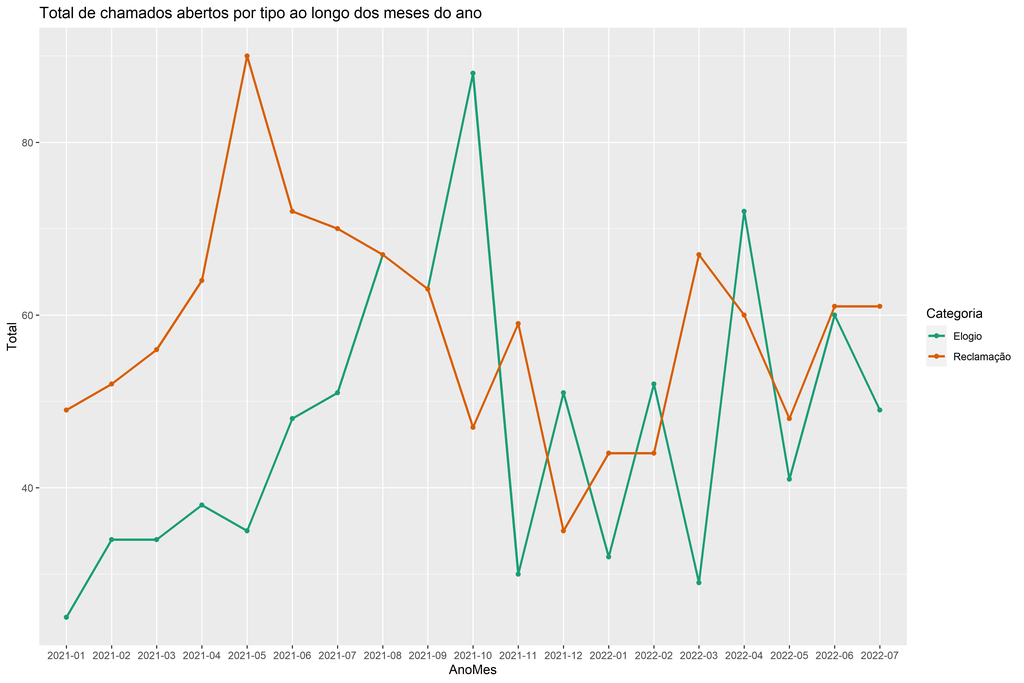

## Visão Reclamações

Aqui são apresentados chamados abertos do tipo **Reclamação**. A ideia desta análise é entender as principais causas das reclamações e suas distribuições ao longo do tempo.

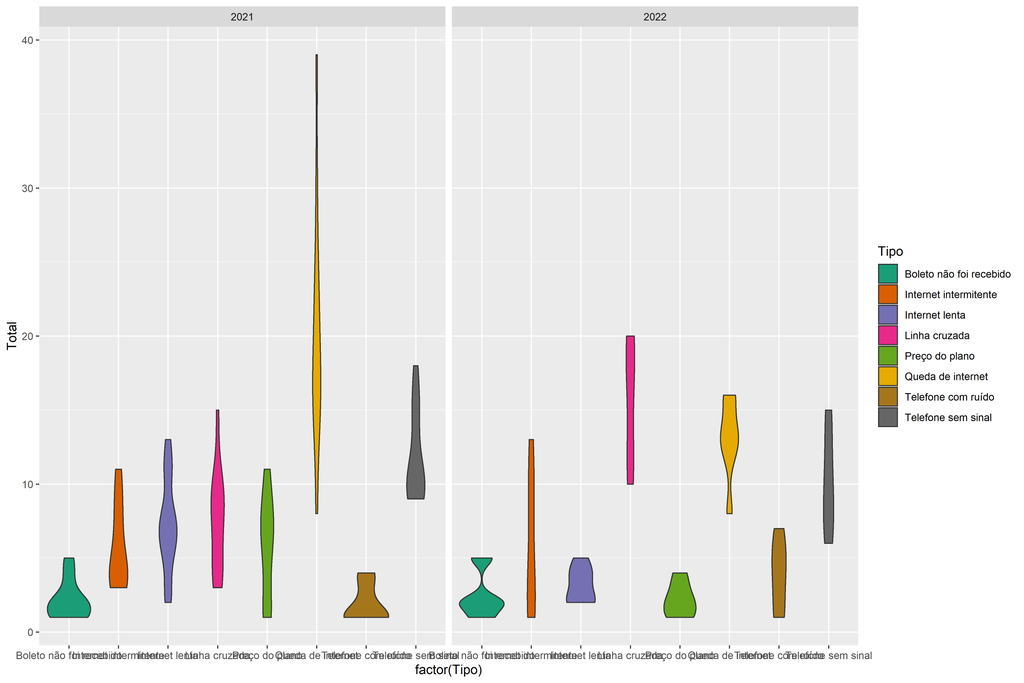

Aqui são apresentados chamados abertos do tipo **Reclamação** por região do Brasil, em que, quanto mais clara é a cor, maior é volume de reclamações vindas dos clientes.

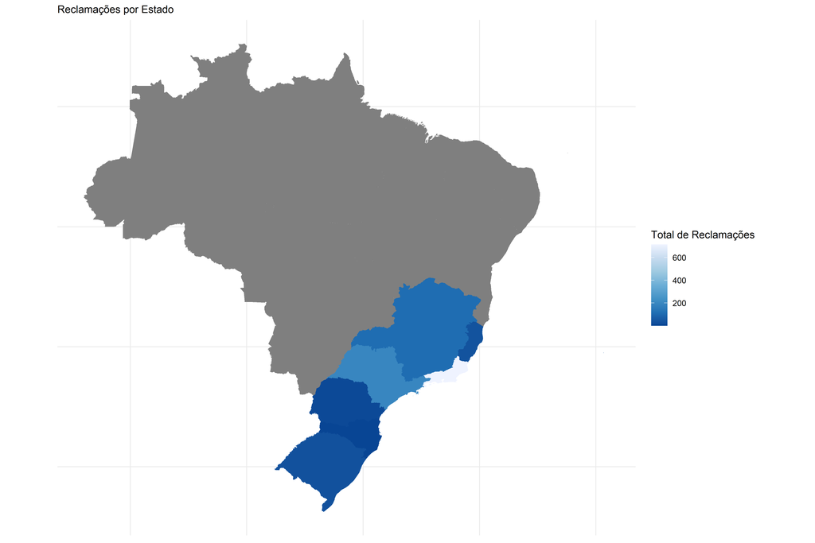